The following examples illustrate the preprocessing of spatial data sets using the sp and raster package.

As always, we start with importing the packages and setting the working directory.

```r
library(gpm)
library(raster)
library(rgdal)
library(sp)

rasterOptions(tmpdir = path_temp)
```

Before we can build a model, we have to extract the raster values (i.e. independent variables) from the satellite dataset. The extraction is based on the polygon layer (ta) which holds the training areas for the prediction. Once everything has been stored in a data frame, it’s time to build the gpm object.

```r
rgb <- stack(paste0(path_aerial_aggregated, "geonode_muf_merged_001m.tif"))
vi <- raster(paste0(path_aerial_aggregated, "muf_merged_001m_visible_vegetation_index.tif"))
rm <- raster(paste0(path_aerial_aggregated, "geonode_muf_merged_001m_redness_index_mean_21.tif"))
sat <- stack(rgb, vi, rm)

ta <- readOGR(paste0(path_landcover_training_areas, "muf_training_final.shp"),
              "muf_training_final")

data <- extract(sat, ta)
summary(data)
saveRDS(data, file = paste0(path_rdata, "muf_training_combined.RDS"))
data <- readRDS(file = paste0(path_rdata, "muf_training_combined.RDS"))

data_cmb <- lapply(seq(length(data)), function(i){
  data.frame(ID = ta@data$ID[i],
             NAME = ta@data$NAME[i],
             data[[i]])
})
data_cmb <- do.call("rbind", data_cmb)
data_cmb <- data_cmb[complete.cases(data_cmb[, c(1,3:7)]),]
```

In order to build the gpm object, some meta information has to be defined. This mainly hold information on which column number to use as response (i.e. dependent) variable and which ones to use as independent variables.

```r
data_cmb$ID <- as.factor(data_cmb$ID)
meta <- createGPMMeta(data_cmb,
                      type = "input",
                      selector = 1, response = 1,
                      independent = c(3:7), meta = NULL)
muf_gpm <- gpm(data_cmb,
               meta, scale = TRUE)
```

Once the gpm object has been created, it can be used as input for computing resamples and splitting the resamples into test and training datasets afterwards. In the following example, only 50 data pairs per land-cover are extracted from the overall dataset and this reampling procedure is repeaded ten times. Afterwards, each of the resamplings is split into a training and testing dataset (each holding 50 percent of the data).

```r
muf_resamples <- resamplingsByVariable(x = muf_gpm@data$input,
                                       resample = 10,
                                       use_selector = TRUE,
                                       selector = muf_gpm@data$input$ID,
                                       grabs = 50)

muf_trte <- splitMultResp(x = muf_gpm@data$input,
                           response = muf_gpm@meta$input$RESPONSE,
                           resamples = muf_resamples,
                           p = 0.50)
```

Once the resampling has been defined, the model tuning and feature selection is handeld by the `trainModel` function.

```r
muf_models <- trainModel(x = muf_gpm,
                         response = muf_gpm@meta$input$RESPONSE,
                         independent = muf_gpm@meta$input$INDEPENDENT,
                         resamples = muf_trte,
                         n_var = c(seq(length(muf_gpm@meta$input$INDEPENDENT))),
                         mthd = "rf",
                         seed_nbr = 1,
                         cv_nbr = 5,
                         var_selection = "indv",
                         filepath_tmp = NULL)
```

Based on the 10 trained models (10 because 10 resamplings have been created above), the variable importance of based on each model can be computed in a scaled (i.e. rainging between 0 and 1) and unscaled manner.

```r
var_imp <- compVarImp(muf_models, scale = FALSE)
var_imp_scale <- compVarImp(muf_models, scale = TRUE)
```

The statistics can further be used to create some variable importants plots. Please note that the heatmap only makes sense if more than one type of response variable has been selected (e.g. if one predicts different classes separately and not within one model).

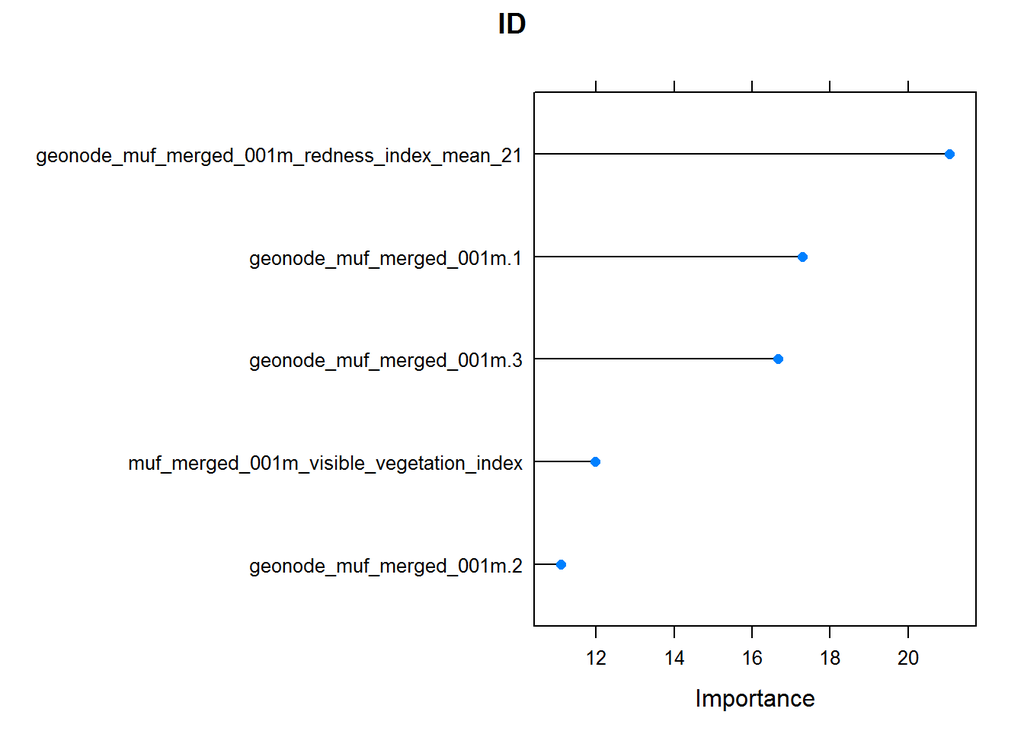

```r
plotVarImp(var_imp)
```

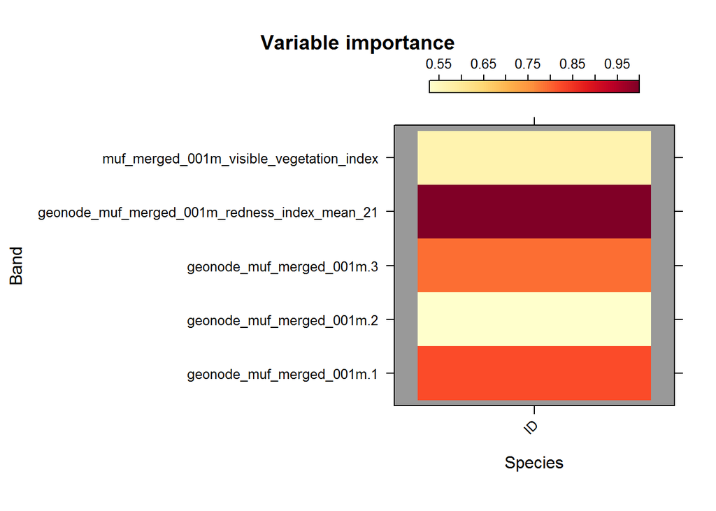

```r
plotVarImpHeatmap(var_imp_scale, xlab = "Species", ylab = "Band")
```

Finally, the performance statistics can be computed for regression or - as in this example - classification models.

```r
tstat <- compContTests(muf_models, mean = TRUE)
summary(tstat[[2]])
```

```
##  Response    Accuracy             Bias             POD
##  ID:10    Min.   :0.002252   Min.   :0.6667   Min.   :0.3333
##           1st Qu.:0.006757   1st Qu.:0.7500   1st Qu.:0.5417
##           Median :0.007883   Median :1.0000   Median :0.8750
##           Mean   :0.008333   Mean   :1.0167   Mean   :0.7750
##           3rd Qu.:0.010698   3rd Qu.:1.0000   3rd Qu.:1.0000
##           Max.   :0.015766   Max.   :2.0000   Max.   :1.0000
##
##       FAR              POFD              SR               TS
##  Min.   :0.0000   Min.   :0.0000   Min.   :0.5000   Min.   :0.2500
##  1st Qu.:0.0000   1st Qu.:0.0000   1st Qu.:0.6667   1st Qu.:0.4250
##  Median :0.2500   Median :0.2500   Median :0.7500   Median :0.6333
##  Mean   :0.2167   Mean   :0.3426   Mean   :0.7833   Mean   :0.6567
##  3rd Qu.:0.3333   3rd Qu.:0.5000   3rd Qu.:1.0000   3rd Qu.:0.9375
##  Max.   :0.5000   Max.   :1.0000   Max.   :1.0000   Max.   :1.0000
##                   NA's   :1
##       ETS               HK               HSS                 OR
##  Min.   :0.2458   Min.   :-0.1667   Min.   :0.002247   Min.   :0.5
##  1st Qu.:0.4177   1st Qu.: 0.2500   1st Qu.:0.006698   1st Qu.:3.0
##  Median :0.6239   Median : 0.3333   Median :0.007812   Median :Inf
##  Mean   :0.6492   Mean   : 0.4074   Mean   :0.008247   Mean   :Inf
##  3rd Qu.:0.9278   3rd Qu.: 0.6667   3rd Qu.:0.010565   3rd Qu.:Inf
##  Max.   :0.9955   Max.   : 1.0000   Max.   :0.015496   Max.   :Inf
##                   NA's   :1                            NA's   :2
##       ORSS             Kappa        Kappa_location   Kappa_histogram
##  Min.   :-0.3333   Min.   :0.3611   Min.   :0.4084   Min.   :0.8519
##  1st Qu.: 0.5000   1st Qu.:0.3762   1st Qu.:0.4323   1st Qu.:0.8617
##  Median : 0.8333   Median :0.3900   Median :0.4481   Median :0.8692
##  Mean   : 0.6667   Mean   :0.3859   Mean   :0.4432   Mean   :0.8708
##  3rd Qu.: 1.0000   3rd Qu.:0.3953   3rd Qu.:0.4540   3rd Qu.:0.8819
##  Max.   : 1.0000   Max.   :0.4028   Max.   :0.4665   Max.   :0.8912
##  NA's   :2
##  Kappa_change_agreement Kappa_quantity_agreement
##  Min.   :2.703          Min.   :0.000e+00
##  1st Qu.:2.703          1st Qu.:0.000e+00
##  Median :2.703          Median :1.735e-16
##  Mean   :2.703          Mean   :1.735e-16
##  3rd Qu.:2.703          3rd Qu.:3.469e-16
##  Max.   :2.703          Max.   :3.469e-16
##
##  Kappa_quantity_disagreement Kappa_allocation_agreement
##  Min.   :10.59               Min.   :35.14
##  1st Qu.:11.49               1st Qu.:36.60
##  Median :12.73               Median :37.95
##  Mean   :12.57               Mean   :37.55
##  3rd Qu.:13.46               3rd Qu.:38.46
##  Max.   :14.41               Max.   :39.19
##
##  Kappa_allocation_disagreement
##  Min.   :44.82
##  1st Qu.:45.95
##  Median :47.07
##  Mean   :47.18
##  3rd Qu.:48.25
##  Max.   :50.90
##
```